# 총, 균, 쇠 — 문명의 지리학

왜 유라시아가 아메리카를 정복했는가

저자

Culture Voyager

공개

2026년 6월 6일

← Culture Voyager 목록으로

**B축 — 인생을 바꾸는 책** · 제레드 다이아몬드 저 · 1997년 초판 / 국내 번역 2005년

## 뉴기니 해변의 질문

1972년. 뉴기니 해변.

조류학자 제레드 다이아몬드는 얄리(Yali)라는 현지 정치인과 함께 해변을 걷고 있었다. 얄리는 영리하고 유머 감각이 넘쳤으며, 서구 세계를 직접 경험한 인물이었다. 그가 갑자기 물었다.

**“왜 당신네 백인들은 그렇게 많은 화물(cargo)을 만들어 이곳으로 가져오는데, 우리 흑인들은 스스로 만든 화물이 그렇게 적은 겁니까?”**

이 질문 앞에서 나는 한참 멈췄다.

솔직히 말하면, 처음 이 대목을 읽었을 때 나는 이미 답을 알고 있다고 생각했다. ‘어, 그거야 역사적으로 식민지배가…’ 혹은 ‘문화적 차이가…’ 같은 흐릿한 서사가 머릿속에서 자동재생됐다. 그런데 다이아몬드는 정확히 그 자동재생 버튼을 누르는 손가락을 멈추게 만든다. 그는 이 질문이 얼마나 뻔뻔하게 회피되어 왔는지를, 얼마나 많은 사람들이 이 질문을 ’불편하다’는 이유로 비틀거나 덮어버렸는지를 조용히 폭로한다.

그리고 500페이지에 걸쳐 하나의 답을 구축한다. 인종이 아니다. 문화도 아니다. 지리다.

## 지도가 운명을 쓴다

지리가 운명이라는 말은 그다지 새롭지 않다. 그런데 다이아몬드가 다른 이유는, 그가 ’지리’를 낭만적 은유가 아니라 생물학적 메커니즘으로 분해하기 때문이다. 이 책은 사실 고생물학, 진화생물학, 역학, 언어학을 한 솥에 끓인 야심찬 요리다. 맛은 다소 강렬하고, 군데군데 타는 냄새가 나기도 하지만.

핵심 논리는 이렇다.

약 1만 년 전, 일부 인류 집단은 수렵채집을 버리고 농경을 시작했다. 농경은 잉여식량을 낳고, 잉여식량은 전업 장인·군인·관료·성직자를 가능하게 했다. 이들이 기술, 국가, 문자를 만들었다. 그렇다면 왜 어떤 집단은 농경을 시작하고 어떤 집단은 그러지 않았는가? 다이아몬드의 답은 명쾌하다. **재배 가능한 야생식물과 가축화 가능한 동물이 있었느냐 없었느냐.**

비옥한 초승달 지대(Fertile Crescent) — 지금의 이라크, 시리아, 터키, 이스라엘 일대 — 는 운 좋게도 밀, 보리, 완두콩, 렌틸콩을 한꺼번에 품고 있었다. 게다가 소, 양, 염소, 돼지, 말까지. 이 지역 사람들은 마치 코스트코 개점 날 첫 번째로 입장한 셈이었다.

아프리카 사하라 이남은? 수수와 얌은 있었지만, 대형 포유류의 대부분이 — 기린, 하마, 코끼리, 얼룩말 — 가축화에 적합하지 않았다. 얼룩말은 성질이 흉포하고, 코끼리는 번식이 느렸으며, 하마는… 그냥 무서웠다. 아메리카 대륙은 더 극단적이다. 라마와 알파카를 빼면 가축화 가능한 대형 포유류가 사실상 전무했다. 말도 없고, 소도 없고, 바퀴도 없었다 — 바퀴가 없었던 건 말이 없어서였다.

운이 나쁜 게 아니었다. 지리가 달랐다. 그리고 지리는 아무도 선택하지 않는다.

## 차트 1 — 대륙별 가축화 가능한 대형 포유류 종수

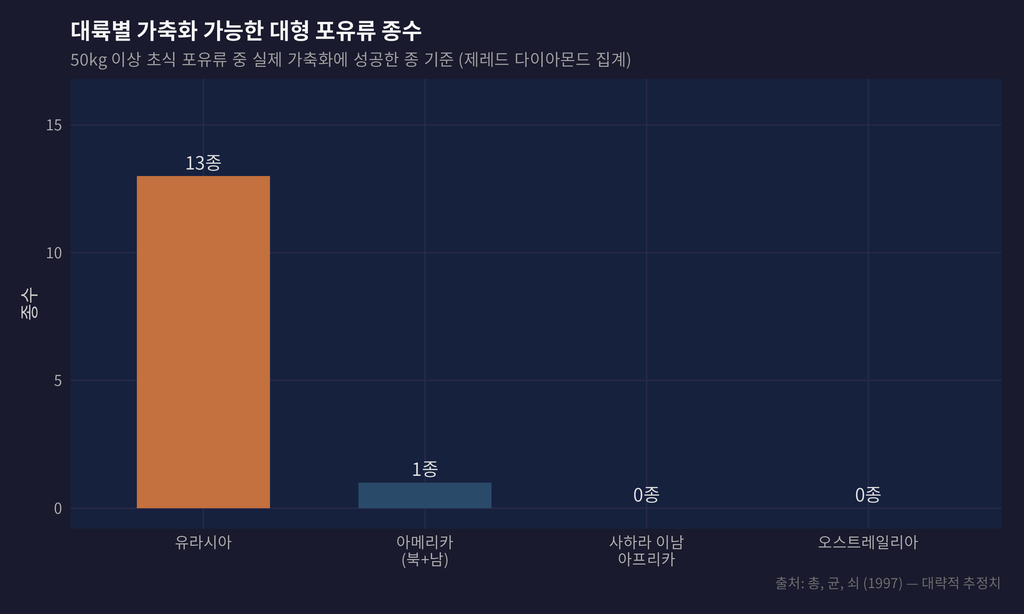

```r
species_data <- data.frame(
  continent = c("유라시아", "사하라 이남\n아프리카", "아메리카\n(북+남)", "오스트레일리아"),
  species_count = c(13, 0, 1, 0),
  highlight = c(TRUE, FALSE, FALSE, FALSE)
)

species_data$continent <- factor(
  species_data$continent,
  levels = c("유라시아", "아메리카\n(북+남)", "사하라 이남\n아프리카", "오스트레일리아")
)

ggplot(species_data, aes(x = continent, y = species_count, fill = highlight)) +
  geom_col(width = 0.6, show.legend = FALSE) +
  geom_text(
    aes(label = ifelse(species_count > 0, paste0(species_count, "종"), "0종")),
    vjust = -0.5, color = "#e0e0e0", size = 4.5, family = "Noto Sans CJK KR"
  ) +
  scale_fill_manual(values = c("#2a4a6a", accent1)) +
  scale_y_continuous(limits = c(0, 16), breaks = seq(0, 15, 5)) +
  labs(
    title = "대륙별 가축화 가능한 대형 포유류 종수",
    subtitle = "50kg 이상 초식 포유류 중 실제 가축화에 성공한 종 기준 (제레드 다이아몬드 집계)",
    x = NULL,
    y = "종수",
    caption = "출처: 총, 균, 쇠 (1997) — 대략적 추정치"
  ) +
  theme_cv() +
  theme(
    axis.text.x = element_text(size = 11)
  )
```

유라시아의 압도적 우위는 기후나 인종이 아니라, 지리적 조건이 빚어낸 생물 다양성의 결과다.

## 동서축 vs. 남북축의 비대칭

이 책에서 내가 가장 머리를 얻어맞은 대목은 ‘대륙의 축’ 이야기다.

유라시아는 동서로 길다. 유럽에서 중국까지 이동해도 위도 차이가 크지 않다. 위도가 비슷하다는 건 기후가 비슷하다는 것이고, 기후가 비슷하면 같은 농작물이 퍼진다. 밀이 터키에서 유럽으로 확산되는 데 수천 년이 걸렸지만, 그래도 퍼졌다. 가축도, 쟁기도, 문자도, 군사 기술도 따라 퍼졌다.

아메리카는 남북으로 길다. 멕시코에서 재배된 옥수수가 북아메리카로 올라오려면 사막과 열대림과 온대 기후를 모두 통과해야 했다. 적도를 넘는 것은 더 어려웠다. 안데스의 라마는 중앙아메리카까지 내려오지 못했다. 농업과 기술의 확산이 수천 킬로미터의 기후 장벽에 막혔다.

아프리카도 남북으로 길다. 사하라 사막이 대륙을 두 쪽으로 갈라놓는다.

## 차트 2 — 대륙 축 방향과 기술 확산 속도

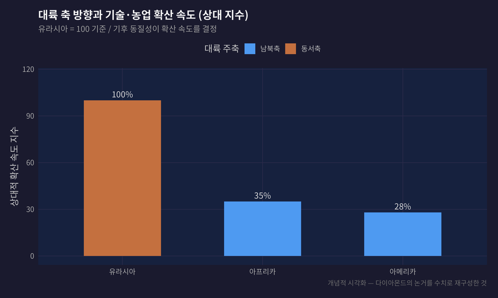

```r
axis_data <- data.frame(
  continent   = c("유라시아", "아메리카", "아프리카"),
  axis        = c("동서축", "남북축", "남북축"),
  diffusion_speed = c(100, 28, 35),  # 상대적 수치 (유라시아 = 100 기준)
  barrier_intensity = c(2, 8, 7)     # 기후 장벽 강도 (1=낮음 ~ 10=높음)
)

# Bar chart for diffusion speed
p1 <- ggplot(axis_data, aes(x = reorder(continent, -diffusion_speed),
                             y = diffusion_speed,
                             fill = axis)) +
  geom_col(width = 0.55) +
  geom_text(
    aes(label = paste0(diffusion_speed, "%")),
    vjust = -0.5, color = "#e0e0e0", size = 4.2, family = "Noto Sans CJK KR"
  ) +
  scale_fill_manual(
    values = c("동서축" = accent1, "남북축" = accent2),
    name = "대륙 주축"
  ) +
  scale_y_continuous(limits = c(0, 115)) +
  labs(
    title = "대륙 축 방향과 기술·농업 확산 속도 (상대 지수)",
    subtitle = "유라시아 = 100 기준 / 기후 동질성이 확산 속도를 결정",
    x = NULL,
    y = "상대적 확산 속도 지수",
    caption = "개념적 시각화 — 다이아몬드의 논거를 수치로 재구성한 것"
  ) +
  theme_cv() +
  theme(legend.position = "top")

p1
```

동서로 뻗은 유라시아는 기후 동질성 덕분에 기술과 작물이 빠르게 퍼졌다. 남북축 대륙들은 기후 장벽이 확산을 막았다.

## 균 — 가장 잔인한 무기

총과 쇠 이야기도 중요하지만, 나는 솔직히 ‘균’ 챕터에서 책을 잠시 내려놓았다. 너무 불편했기 때문이다.

1519년, 에르난 코르테스는 600명의 스페인 병사를 이끌고 아즈텍 제국에 상륙했다. 아즈텍의 인구는 수백만. 상식적으로 600명이 이길 수 없는 싸움이었다. 그런데 코르테스는 이겼다. 총과 말과 강철 갑옷이 도움이 됐다. 하지만 진짜 무기는 그들의 몸속에 있었다.

스페인 병사들은 수천 년간 소·양·돼지와 함께 살아오면서 천연두, 홍역, 인플루엔자, 페스트에 대한 면역을 획득했다. 아즈텍인들은 그런 동물과 함께 산 역사가 없었다. 면역이 없었다. 코르테스가 멕시코 내륙으로 진군하는 동안, 그의 병사들이 지나친 마을마다 사람들이 쓰러졌다. 코르테스가 직접 싸우기도 전에, 전쟁은 이미 끝나 있었다.

## 차트 3 — 아메리카 원주민 인구 감소 (유럽인 접촉 이후)

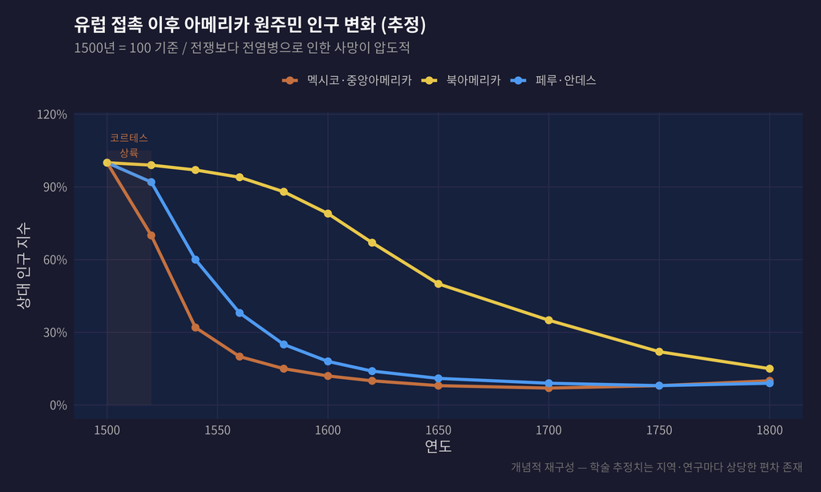

```r
mortality_data <- data.frame(
  year = c(1500, 1520, 1540, 1560, 1580, 1600, 1620, 1650, 1700, 1750, 1800),
  mexico_central = c(100, 70, 32, 20, 15, 12, 10, 8, 7, 8, 10),
  peru_andes     = c(100, 92, 60, 38, 25, 18, 14, 11, 9, 8, 9),
  north_america  = c(100, 99, 97, 94, 88, 79, 67, 50, 35, 22, 15)
)

mortality_long <- mortality_data %>%
  pivot_longer(
    cols = c(mexico_central, peru_andes, north_america),
    names_to = "region",
    values_to = "population_index"
  ) %>%
  mutate(
    region_label = case_when(
      region == "mexico_central" ~ "멕시코·중앙아메리카",
      region == "peru_andes"     ~ "페루·안데스",
      region == "north_america"  ~ "북아메리카"
    )
  )

ggplot(mortality_long, aes(x = year, y = population_index,
                            color = region_label, group = region_label)) +
  geom_line(linewidth = 1.3) +
  geom_point(size = 2.5) +
  annotate(
    "rect",
    xmin = 1500, xmax = 1520, ymin = 0, ymax = 105,
    fill = accent1, alpha = 0.08
  ) +
  annotate(
    "text", x = 1510, y = 107, label = "코르테스\n상륙",
    color = accent1, size = 3.2, family = "Noto Sans CJK KR", hjust = 0.5
  ) +
  scale_color_manual(
    values = c(
      "멕시코·중앙아메리카" = accent1,
      "페루·안데스"         = accent2,
      "북아메리카"          = accent4
    ),
    name = NULL
  ) +
  scale_y_continuous(
    limits = c(0, 115),
    labels = function(x) paste0(x, "%")
  ) +
  scale_x_continuous(breaks = seq(1500, 1800, 50)) +
  labs(
    title = "유럽 접촉 이후 아메리카 원주민 인구 변화 (추정)",
    subtitle = "1500년 = 100 기준 / 전쟁보다 전염병으로 인한 사망이 압도적",
    x = "연도",
    y = "상대 인구 지수",
    caption = "개념적 재구성 — 학술 추정치는 지역·연구마다 상당한 편차 존재"
  ) +
  theme_cv() +
  theme(legend.position = "top")
```

코르테스가 멕시코에 도착한 직후 수십 년 만에 인구의 80-90%가 사라졌다. 총보다 균이 더 빠르고 확실한 정복자였다.

## 한반도를 지도 위에 놓아보기

이 책을 읽으면서 나는 자꾸 한반도로 시선이 돌아갔다.

한반도는 지리적으로 기묘한 위치다. 중국이라는 거대한 대륙 문명의 곁에, 일본이라는 섬나라의 위쪽에. 다이아몬드의 프레임으로 보면, 한반도는 유라시아 동서축의 수혜를 부분적으로 받은 지역이다. 농경 기술, 철기, 문자가 중국으로부터 흘러왔다. 한국은 뉴기니가 아니었다. 유라시아의 동쪽 끄트머리에서 대륙의 지식을 흡수하는 위치였다.

그런데 동시에, 그 위치 때문에 한반도는 끝없이 침략을 받았다. 대륙의 세력이 바다로 나가려면 한반도를 거쳐야 했고, 섬나라가 대륙을 치려면 한반도를 교두보로 삼았다. 지리가 문명을 선물했고, 같은 지리가 전쟁을 선물했다.

조금 쓸쓸한 생각이 든다. 다이아몬드의 논리대로라면, 한국이 그 반도에 위치한 것도, 그 반도가 그 강대국들 사이에 끼어 있는 것도, 어느 누구의 선택도 아니다. 지리가 그렇게 생겼을 뿐이다.

지리는 죄가 없다. 하지만 지리 때문에 죄를 짊어진 사람들이 있다.

## 다이아몬드가 틀린 것들

이쯤 되면 이 책이 완벽한 걸작처럼 느껴지지만, 나는 독자로서 적당히 삐딱한 시선을 유지할 책임이 있다.

**첫째, 행위성(agency)의 실종.** 다이아몬드의 설명은 지나치게 구조적이다. 지리와 생태가 결정하고, 인간은 거의 반응하는 수동적 존재처럼 그려진다. 하지만 같은 지리 조건을 가졌어도 어떤 사회는 그 조건을 활용했고 어떤 사회는 그러지 않았다. 일본과 한국은 비슷한 위도에 있었지만, 메이지 유신과 조선의 대응은 달랐다. 지리만으로는 그 차이를 설명할 수 없다.

**둘째, ‘가축화 가능한 동물’ 논리의 순환성.** 다이아몬드는 특정 동물이 가축화에 실패한 이유를 설명하면서 — 얼룩말이 공격적이라서, 곰이 번식이 느려서 등 — 때로는 ’가축화에 성공한 동물 = 원래부터 가축화 가능했던 동물’이라는 순환논리에 빠지기도 한다. 왜 우리가 말은 길들였는데 얼룩말은 못 길들였는지에 대한 설명이 ’얼룩말은 원래 그래서’가 되는 순간, 논증이 약해진다.

**셋째, 최근 수백 년의 설명력 약화.** 다이아몬드의 프레임은 기원전 1만 년에서 기원후 1500년 사이를 설명하는 데 강력하다. 그런데 산업혁명 이후, 혹은 20세기 이후를 보면 지리 결정론의 설명력이 급격히 떨어진다. 싱가포르는 자원이 없고, 이스라엘은 사막이고, 한국은 전쟁으로 폐허가 됐다. 오늘날의 경제적 성과는 지리보다 제도와 교육과 정치에 더 많이 달려 있다는 주장이 적지 않다.

**넷째, 아프리카 서술의 편향.** 책의 절반 이상이 사실상 ’왜 유라시아가 아메리카를 이겼는가’에 집중되어 있고, 아프리카는 반쪽짜리 분석만 받는다. 아프리카 내부의 다양성 — 이집트, 악숨, 말리, 짐바브웨 왕국들 — 은 지리 결정론으로 설명하기 어려운 것들이 많다.

## 인터넷 시대에도 지리는 중요한가

이 질문에 다이아몬드는 직접 답하지 않는다. 책이 1997년에 나왔으니까. 그렇다면 우리가 답해야 한다.

처음에는 ’당연히 아니다’는 생각이 든다. 인터넷은 정보의 지리적 장벽을 허물었다. 서울에서 실리콘밸리의 스타트업 생태계를 그대로 복사하는 것이 가능해졌다. 케냐의 창업자가 샌프란시스코의 투자자에게 피치덱을 보내는 데 위도는 아무 상관이 없다.

하지만 잠깐. 데이터센터는 어디에 있는가? 해저 광케이블은 어느 항구를 지나는가? 반도체 공장은 지리적 위험이 낮고 물이 풍부하며 고급 인력이 있는 곳에 지어진다. 최근 지정학의 귀환 — 반도체 공급망, 희토류 통제, 항만 패권 — 을 보면, 지리는 사라지지 않았다. 형태를 바꿨을 뿐이다.

다이아몬드의 진짜 공헌은 어쩌면 ’지리가 결정한다’는 결론이 아니라, ’왜 이런 질문을 우리는 피해왔는가’라는 도발일지 모른다.

## 다큐멘터리 — 화면으로 만나는 총, 균, 쇠

이 책은 2005년 내셔널 지오그래픽과 PBS가 공동으로 3부작 다큐멘터리로 제작했다. 다이아몬드가 직접 뉴기니, 아프리카, 아메리카를 돌아다니며 현장에서 논증을 펼친다. 책이 지루하게 느껴진다면, 이 영상이 입문으로 더 좋다.

[video not shown]

총, 균, 쇠 다큐멘터리 1부 — PBS/내셔널 지오그래픽 (2005)

## 차트 4 — 비옥한 초승달 지대의 작물 다양성

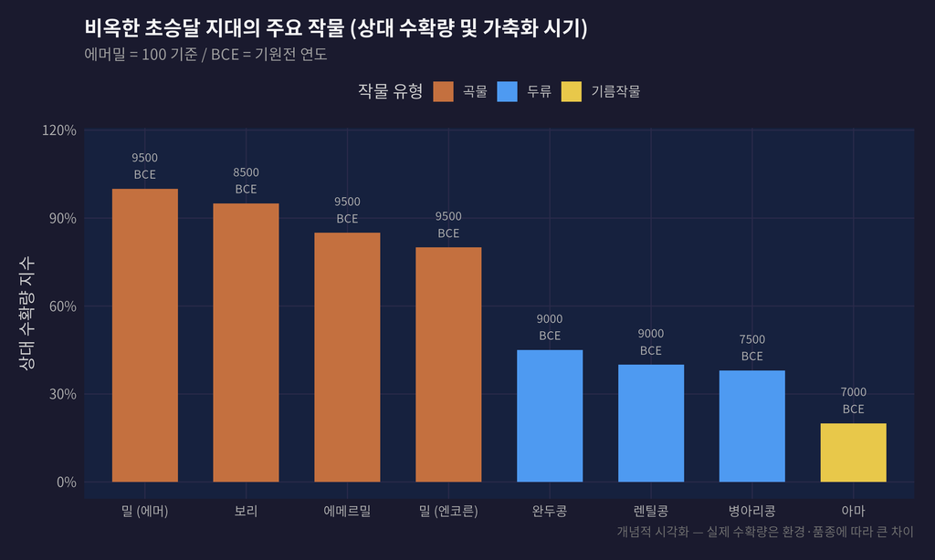

```r
crop_data <- data.frame(
  crop_type = c(
    "밀 (에머)", "밀 (엔코른)", "보리",
    "완두콩", "렌틸콩", "병아리콩",
    "아마", "에메르밀"
  ),
  region = c(
    "곡물", "곡물", "곡물",
    "두류", "두류", "두류",
    "기름작물", "곡물"
  ),
  domestication_year_bce = c(9500, 9500, 8500, 9000, 9000, 7500, 7000, 9500),
  yield_relative = c(100, 80, 95, 45, 40, 38, 20, 85)
)

crop_data$region <- factor(
  crop_data$region,
  levels = c("곡물", "두류", "기름작물")
)

ggplot(
  crop_data,
  aes(
    x = reorder(crop_type, -yield_relative),
    y = yield_relative,
    fill = region
  )
) +
  geom_col(width = 0.65) +
  geom_text(
    aes(label = paste0(domestication_year_bce, "\nBCE")),
    vjust = -0.4, size = 3.2, color = "#b0b0b0",
    family = "Noto Sans CJK KR"
  ) +
  scale_fill_manual(
    values = c("곡물" = accent1, "두류" = accent2, "기름작물" = accent4),
    name = "작물 유형"
  ) +
  scale_y_continuous(
    limits = c(0, 115),
    labels = function(x) paste0(x, "%")
  ) +
  labs(
    title = "비옥한 초승달 지대의 주요 작물 (상대 수확량 및 가축화 시기)",
    subtitle = "에머밀 = 100 기준 / BCE = 기원전 연도",
    x = NULL,
    y = "상대 수확량 지수",
    caption = "개념적 시각화 — 실제 수확량은 환경·품종에 따라 큰 차이"
  ) +
  theme_cv() +
  theme(
    axis.text.x = element_text(size = 10),
    legend.position = "top"
  )
```

한 지역에 이렇게 많은 고칼로리 작물이 집중된 것은 역사의 우연이 아니라 지리·기후의 축복이었다.

## 자유의지는 어디에 있는가

책을 덮으면서 나는 이상하게 무거운 기분이 됐다.

다이아몬드의 주장이 완전히 옳다면 — 지리가 운명이라면 — 우리는 무엇을 할 수 있는가? 얄리가 뉴기니에서 태어난 건 그의 잘못이 아니다. 코르테스의 조상들이 비옥한 초승달 지대 근처에서 밀을 재배한 것도 그의 공이 아니다. 모든 게 위도와 생태와 우연이라면, 도덕적 책임은 어디로 가는가?

다이아몬드는 이 불편함을 정면으로 다루지 않는다. 그는 과학자의 자세로 ’어떻게’를 설명하고, ’그래서 어쩌라고’는 독자에게 넘긴다. 그 공백이 이 책의 가장 솔직한 대목이기도 하고, 가장 무책임한 대목이기도 하다.

내 생각은 이렇다. 지리가 출발선을 결정했다는 것, 그래서 어떤 사회는 더 유리한 출발선에 섰다는 것을 인정하는 것이 첫 번째 단계다. 그 인정 없이는 오늘날의 불평등을 ‘그들의 문화 탓’, ’그들의 능력 탓’으로 돌리는 안이함에서 벗어날 수 없다.

하지만 출발선이 다르다는 것이 현재의 불평등을 영구화하는 이유가 되어서는 안 된다. 다이아몬드가 분석한 것은 ’왜 이렇게 됐는가’이지, ’이렇게 있어야 한다’가 아니다. 과거의 지리 결정론을 현재의 무기력 혹은 체념으로 변환하는 것은 독자의 실수다.

그리고 여기서 한국의 사례가 다시 떠오른다. 반도라는 지리, 자원 빈국, 분단이라는 조건. 이 조건들이 한국을 특정 운명으로 밀어 넣는 것처럼 보이던 때가 분명히 있었다. 하지만 그 운명을 거스른 세대가 있었다. 완전히 거스른 것도 아니고, 때로는 그 운명의 흐름에 올라탄 것도 있지만, 어쨌든 지도가 전부가 아님을 증명했다.

지도는 가능성의 구조를 그린다. 그 안에서 무엇을 할지는 여전히 인간의 몫이다. 너무 뻔한 결론인가? 뻔하지만 틀리지 않았다.

## 마지막으로 — 이 책이 불편한 이유

이 책이 출간됐을 때 일부에서는 “지리 결정론은 제국주의의 변명”이라는 비판이 나왔다. 다른 한편에서는 “인종주의적 편견을 해체했다”는 찬사도 나왔다. 같은 책이 상반된 반응을 불러일으킨다는 것은 — 그것이 진짜 불편한 진실을 건드렸다는 신호다.

인종이 지능과 문명 수준을 결정한다는 생각은 명백한 거짓말이다. 다이아몬드는 그 거짓말을 조목조목 해부했다. 그 점에서 이 책은 중요하고, 지금도 읽혀야 한다. 하지만 인종 결정론을 지리 결정론으로 교체하는 것만으로 충분한가? 구조가 어떻든 개인과 공동체의 선택이 개입할 여지를 완전히 소거하는 것이 과연 더 나은 세계관인가?

나는 이 책을 읽고 세 가지가 생겼다. 지식, 불편함, 그리고 질문. 좋은 책이 하는 일이 딱 그거다.

## 함께 읽으면 좋은 책

이 책의 주장에 동의하든 동의하지 않든, 다음 책들과 함께 읽으면 더 풍부한 긴장이 생긴다.

- **사피엔스** — 유발 하라리 : 같은 인류 문명사를 완전히 다른 각도(인지혁명·허구의 힘)에서 본다
- **국가는 왜 실패하는가** — 애서모글루·로빈슨 : 지리보다 제도가 중요하다는 정반대 논지
- **문명의 충돌** — 헌팅턴 : 지리도 인종도 아닌 ’문명권’으로 세계를 나누는 또 다른 거대서사
- **총, 균, 쇠** 이후 다이아몬드 본인이 쓴 **문명의 붕괴** : 환경 결정론의 다른 면 — 사회가 어떻게 자기 환경을 파괴하며 무너지는가

← Culture Voyager 목록으로 돌아가기

**데이터 및 시각화 주석**

차트 렌더링: R `ggplot2` / 폰트: Noto Sans CJK KR / 렌더러: `ragg_png`